# 1주차 패키지

## Chapter 1

### 문제0

데이터 불러오기

```r
setwd("C:/Users/user/Desktop/weekly packages/1week")
library(data.table)
library(tidyverse)
data <- fread("data.csv",colClasses = c(patient_id = "character"))
data %>% head()
```

```
##    patient_id    sex age country province   city confirmed_date    state
## 1: 1000000001   male 50s   Korea     서울 강서구     2020-01-23 released
## 2: 1000000002   male 30s   Korea     서울 중랑구     2020-01-30 released
## 3: 1000000003   male 50s   Korea     서울 종로구     2020-01-30 released
## 4: 1000000004   male 20s   Korea     서울 마포구     2020-01-30 released
## 5: 1000000005 female 20s   Korea     서울 성북구     2020-01-31 released
## 6: 1000000006 female 50s   Korea     서울 종로구     2020-01-31 released
```

## 문제1

데이터 확인

```r
library(tidyverse)
data %>% str()
```

```
## Classes 'data.table' and 'data.frame':   5165 obs. of  8 variables:
##  $ patient_id    : chr  "1000000001" "1000000002" "1000000003" "1000000004" ...
##  $ sex           : chr  "male" "male" "male" "male" ...
##  $ age           : chr  "50s" "30s" "50s" "20s" ...
##  $ country       : chr  "Korea" "Korea" "Korea" "Korea" ...
##  $ province      : chr  "서울" "서울" "서울" "서울" ...
##  $ city          : chr  "강서구" "중랑구" "종로구" "마포구" ...
##  $ confirmed_date: IDate, format: "2020-01-23" "2020-01-30" ...
##  $ state         : chr  "released" "released" "released" "released" ...
##  - attr(*, ".internal.selfref")=<externalptr>
```

```r
data %>% is.na() %>% colSums()
```

```
##     patient_id            sex            age        country       province
##              0              0              0              0              0
##           city confirmed_date          state
##              0              3              0
```

```r
data$patient_id %>% unique() %>% length()
```

```
## [1] 5164
```

```r
data$sex %>% unique() %>% length()
```

```
## [1] 3
```

```r
data$age %>% unique() %>% length()
```

```
## [1] 12
```

```r
data$country %>% unique() %>% length()
```

```
## [1] 16
```

```r
data$province %>% unique() %>% length()
```

```
## [1] 17
```

```r
data$city %>% unique() %>% length()
```

```
## [1] 163
```

```r
data$confirmed_date %>% unique() %>% length()
```

```
## [1] 149
```

```r
data$state %>% unique() %>% length()
```

```
## [1] 3
```

## 문제1

### 다른 방법

```r
x<-apply(data,2,unique)
sapply(x,length)
```

```
##     patient_id            sex            age        country       province
##           5164              3             12             16             17
##           city confirmed_date          state
##            163            149              3
```

## 문제2-1

NA행 제거

```r
library(plyr)
data2<-data %>% filter(!is.na(confirmed_date))
data2 %>% is.na() %>% colSums()
```

```
##     patient_id            sex            age        country       province
##              0              0              0              0              0
##           city confirmed_date          state
##              0              0              0
```

```r
data[complete.cases(data)==T,]
```

```
##       patient_id    sex age    country province   city confirmed_date    state
##    1: 1000000001   male 50s      Korea     서울 강서구     2020-01-23 released
##    2: 1000000002   male 30s      Korea     서울 중랑구     2020-01-30 released
##    3: 1000000003   male 50s      Korea     서울 종로구     2020-01-30 released
##    4: 1000000004   male 20s      Korea     서울 마포구     2020-01-30 released
##    5: 1000000005 female 20s      Korea     서울 성북구     2020-01-31 released
##   ---
## 5158: 7000000015 female 30s      Korea   제주도 제주도     2020-05-30 released
## 5159: 7000000016                 Korea   제주도 제주도     2020-06-16 released
## 5160: 7000000017            Bangladesh   제주도 제주도     2020-06-18 isolated
## 5161: 7000000018            Bangladesh   제주도 제주도     2020-06-18 isolated
## 5162: 7000000019            Bangladesh   제주도 제주도     2020-06-18 isolated
```

## 문제 2-2

빈행 제거 및 NA개수와 Unique값 및 개수 확인

```r
library(plyr)
data2$confirmed_date<-as.character(data2$confirmed_date)
data2$confirmed_date!=""
```

[output not shown]

[output cut: 354 more lines]

```r
data2 %>% str()
```

```
## Classes 'data.table' and 'data.frame':   5162 obs. of  8 variables:
##  $ patient_id    : chr  "1000000001" "1000000002" "1000000003" "1000000004" ...
##  $ sex           : chr  "male" "male" "male" "male" ...
##  $ age           : chr  "50s" "30s" "50s" "20s" ...
##  $ country       : chr  "Korea" "Korea" "Korea" "Korea" ...
##  $ province      : chr  "서울" "서울" "서울" "서울" ...
##  $ city          : chr  "강서구" "중랑구" "종로구" "마포구" ...
##  $ confirmed_date: chr  "2020-01-23" "2020-01-30" "2020-01-30" "2020-01-30" ...
##  $ state         : chr  "released" "released" "released" "released" ...
##  - attr(*, ".internal.selfref")=<externalptr>
```

```r
data3<-data2[which(data2$patient_id!=""&data2$sex!=""&data2$age!=""&data2$country!=""&data2$province!=""&data2$city!=""&data2$confirmed_date!=""&data2$state!=""),]

y<-apply(data3,2,unique)
y
```

```
## $patient_id
##    [1] "1000000001" "1000000002" "1000000003" "1000000004" "1000000005"
##    [6] "1000000006" "1000000007" "1000000008" "1000000009" "1000000010"
##   [11] "1000000011" "1000000012" "1000000013" "1000000014" "1000000015"
##   [16] "1000000016" "1000000017" "1000000018" "1000000019" "1000000020"
##   [21] "1000000021" "1000000022" "1000000023" "1000000024" "1000000025"
##   [26] "1000000026" "1000000027" "1000000028" "1000000029" "1000000030"
##   [31] "1000000031" "1000000032" "1000000033" "1000000034" "1000000035"
##   [36] "1000000036" "1000000037" "1000000038" "1000000039" "1000000040"
##   [41] "1000000041" "1000000042" "1000000043" "1000000044" "1000000045"
##   [46] "1000000046" "1000000047" "1000000048" "1000000049" "1000000050"
##   [51] "1000000051" "1000000052" "1000000053" "1000000054" "1000000055"
##   [56] "1000000056" "1000000057" "1000000058" "1000000059" "1000000060"
##   [61] "1000000061" "1000000062" "1000000063" "1000000064" "1000000065"
##   [66] "1000000066" "1000000067" "1000000068" "1000000069" "1000000070"
```

[output cut: 805 more lines]

```r
sapply(y,length)
```

```
##     patient_id            sex            age        country       province
##           3689              2             11             15             16
##           city confirmed_date          state
##            158            145              3
```

## 문제 3

country열 제거

```r
data4<-data3[which(data3$country=="Korea"),]
data5<-data4[,-c("country")]
```

## 문제4

값 바꾸기

```r
data5$province[data5$province=="서울"] <- "서울특별시"
data5$province[data5$province=="부산"] <- "부산광역시"
data5$province[data5$province=="대구"] <- "대구광역시"
data5$province[data5$province=="인천"] <- "인천광역시"
data5$province[data5$province=="대전"] <- "대전광역시"
data5$province[data5$province=="세종"] <- "세종특별자치시"
data5$province[data5$province=="울산"] <- "울산광역시"
data5$province[data5$province=="제주도"] <- "제주특별자치도"
```

## 문제5

자료형으로 변환

```r
data5$confirmed_date<-as.Date(data5$confirmed_date)
data5 %>% str
```

```
## Classes 'data.table' and 'data.frame':   3653 obs. of  7 variables:
##  $ patient_id    : chr  "1000000001" "1000000002" "1000000003" "1000000004" ...
##  $ sex           : chr  "male" "male" "male" "male" ...
##  $ age           : chr  "50s" "30s" "50s" "20s" ...
##  $ province      : chr  "서울특별시" "서울특별시" "서울특별시" "서울특별시" ...
##  $ city          : chr  "강서구" "중랑구" "종로구" "마포구" ...
##  $ confirmed_date: Date, format: "2020-01-23" "2020-01-30" ...
##  $ state         : chr  "released" "released" "released" "released" ...
##  - attr(*, ".internal.selfref")=<externalptr>
```

## 문제6

파생변수 생성(confirmed_number)

```r
conf_df<-table(data5$confirmed_date) ; conf_df   #table - > counting해줌.
```

```
##
## 2020-01-23 2020-01-26 2020-01-27 2020-01-30 2020-01-31 2020-02-02 2020-02-05
##          1          1          1          4          3          2          4
## 2020-02-06 2020-02-07 2020-02-09 2020-02-16 2020-02-18 2020-02-19 2020-02-20
##          1          1          2          2          8         19         28
## 2020-02-21 2020-02-22 2020-02-23 2020-02-24 2020-02-25 2020-02-26 2020-02-27
##         33         65         72         55         90        117        110
## 2020-02-28 2020-02-29 2020-03-01 2020-03-02 2020-03-03 2020-03-04 2020-03-05
##        133         98        127         65        112        115        143
## 2020-03-06 2020-03-07 2020-03-08 2020-03-09 2020-03-10 2020-03-11 2020-03-12
##         99         56         52         69         95         51         35
## 2020-03-13 2020-03-14 2020-03-15 2020-03-16 2020-03-17 2020-03-18 2020-03-19
##         35         33         37         53         42         56         49
## 2020-03-20 2020-03-21 2020-03-22 2020-03-23 2020-03-24 2020-03-25 2020-03-26
##         72         38         31         23         54         47         48
## 2020-03-27 2020-03-28 2020-03-29 2020-03-30 2020-03-31 2020-04-01 2020-04-02
##         46         66         55         46         71         47         57
## 2020-04-03 2020-04-04 2020-04-05 2020-04-06 2020-04-07 2020-04-08 2020-04-09
##         47         42         27         14         24         13         18
## 2020-04-10 2020-04-11 2020-04-12 2020-04-13 2020-04-14 2020-04-15 2020-04-16
##         13          9         10         14         13         12          8
## 2020-04-17 2020-04-18 2020-04-19 2020-04-20 2020-04-21 2020-04-22 2020-04-23
##         10          4          6          5          8          7          5
## 2020-04-24 2020-04-25 2020-04-26 2020-04-27 2020-04-28 2020-04-29 2020-04-30
##          7          8          5          4          6          1          2
## 2020-05-01 2020-05-02 2020-05-03 2020-05-05 2020-05-06 2020-05-07 2020-05-08
##          1          7          2          1          3          6          6
## 2020-05-09 2020-05-10 2020-05-11 2020-05-12 2020-05-13 2020-05-14 2020-05-15
##          9          6         17         10         10          9          4
## 2020-05-16 2020-05-17 2020-05-18 2020-05-19 2020-05-20 2020-05-21 2020-05-22
##          6          5          8         10          6          7         19
## 2020-05-23 2020-05-24 2020-05-25 2020-05-26 2020-05-27 2020-05-28 2020-05-29
##         11          9          7          8         25         24         19
## 2020-05-30 2020-05-31 2020-06-01 2020-06-02 2020-06-04 2020-06-05 2020-06-06
##          2          2          4          6          3          4          2
## 2020-06-07 2020-06-08 2020-06-09 2020-06-11 2020-06-12 2020-06-13 2020-06-14
##          1          3          3          1          3          4          4
## 2020-06-15 2020-06-16 2020-06-17 2020-06-18 2020-06-19 2020-06-20 2020-06-21
##          6          8         11          8         15         14          6
## 2020-06-22 2020-06-23 2020-06-24 2020-06-25 2020-06-26 2020-06-27 2020-06-28
##          6         13          9          9          4         12          8
## 2020-06-29 2020-06-30
##          6          4
```

```r
conf_df<-as.data.frame(conf_df)
colnames(conf_df) <- c("confirmed_date", "confirmed_number"); conf_df
```

```
##     confirmed_date confirmed_number
## 1       2020-01-23                1
## 2       2020-01-26                1
## 3       2020-01-27                1
## 4       2020-01-30                4
## 5       2020-01-31                3
## 6       2020-02-02                2
## 7       2020-02-05                4
## 8       2020-02-06                1
## 9       2020-02-07                1
## 10      2020-02-09                2
## 11      2020-02-16                2
## 12      2020-02-18                8
## 13      2020-02-19               19
## 14      2020-02-20               28
```

[output cut: 128 more lines]

```r
conf_df$confirmed_date<-as.Date(conf_df$confirmed_date)
data6<-left_join(data5,conf_df,by='confirmed_date')
data6
```

```
##       patient_id    sex age       province   city confirmed_date    state
##    1: 1000000001   male 50s     서울특별시 강서구     2020-01-23 released
##    2: 1000000002   male 30s     서울특별시 중랑구     2020-01-30 released
##    3: 1000000003   male 50s     서울특별시 종로구     2020-01-30 released
##    4: 1000000004   male 20s     서울특별시 마포구     2020-01-30 released
##    5: 1000000005 female 20s     서울특별시 성북구     2020-01-31 released
##   ---
## 3649: 7000000010 female 20s 제주특별자치도 제주도     2020-04-03 released
## 3650: 7000000011   male 30s 제주특별자치도 제주도     2020-04-03 released
## 3651: 7000000012 female 20s 제주특별자치도 제주도     2020-04-03 released
## 3652: 7000000014 female 30s 제주특별자치도 제주도     2020-05-09 released
## 3653: 7000000015 female 30s 제주특별자치도 제주도     2020-05-30 released
##       confirmed_number
##    1:                1
##    2:                4
##    3:                4
##    4:                4
##    5:                3
##   ---
## 3649:               47
## 3650:               47
## 3651:               47
## 3652:                9
## 3653:                2
```

## 문제7

파생변수 생성(wday)

```r
weekdays1 <- c('월요일', '화요일', '수요일', '목요일', '금요일')
data6$wDay = factor((weekdays(data5$confirmed_date) %in% weekdays1),levels=c(FALSE, TRUE), labels=c('주말', '주중'))
```

## 문제8

나이대별 일별 확진자 수 summary

```r
tapply(data6$confirmed_date,data6$age,count)
```

```
## $`0s`
##             x freq
## 1  2020-02-24    1
## 2  2020-02-26    1
## 3  2020-02-27    1
## 4  2020-02-28    1
## 5  2020-02-29    3
## 6  2020-03-01    3
## 7  2020-03-02    1
## 8  2020-03-03    1
## 9  2020-03-04    2
## 10 2020-03-05    3
## 11 2020-03-06    2
## 12 2020-03-07    2
## 13 2020-03-08    2
```

[output cut: 808 more lines]

```r
with(data6,tapply(confirmed_date,age,count))
```

```
## $`0s`
##             x freq
## 1  2020-02-24    1
## 2  2020-02-26    1
## 3  2020-02-27    1
## 4  2020-02-28    1
## 5  2020-02-29    3
## 6  2020-03-01    3
## 7  2020-03-02    1
## 8  2020-03-03    1
## 9  2020-03-04    2
## 10 2020-03-05    3
## 11 2020-03-06    2
## 12 2020-03-07    2
## 13 2020-03-08    2
```

[output cut: 808 more lines]

```r
with(data6,tapply(confirmed_date,age,function(x){summary(count(x)$freq)}))
```

```
## $`0s`
##    Min. 1st Qu.  Median    Mean 3rd Qu.    Max.
##   1.000   1.000   1.000   1.488   2.000   3.000
##
## $`100s`
##    Min. 1st Qu.  Median    Mean 3rd Qu.    Max.
##       1       1       1       1       1       1
##
## $`10s`
##    Min. 1st Qu.  Median    Mean 3rd Qu.    Max.
##   1.000   1.000   2.000   2.276   3.000   8.000
##
## $`20s`
##    Min. 1st Qu.  Median    Mean 3rd Qu.    Max.
##   1.000   1.000   3.500   7.526  11.000  43.000
##
## $`30s`
##    Min. 1st Qu.  Median    Mean 3rd Qu.    Max.
##   1.000   2.000   3.000   5.051   8.000  17.000
##
## $`40s`
##    Min. 1st Qu.  Median    Mean 3rd Qu.    Max.
##   1.000   1.000   2.000   4.931   6.000  33.000
##
## $`50s`
##    Min. 1st Qu.  Median    Mean 3rd Qu.    Max.
##   1.000   1.000   3.000   6.112   9.000  31.000
##
## $`60s`
##    Min. 1st Qu.  Median    Mean 3rd Qu.    Max.
##   1.000   1.000   3.000   4.722   7.000  22.000
##
## $`70s`
##    Min. 1st Qu.  Median    Mean 3rd Qu.    Max.
##   1.000   1.000   2.000   2.908   3.250  13.000
##
## $`80s`
##    Min. 1st Qu.  Median    Mean 3rd Qu.    Max.
##   1.000   1.000   2.000   3.019   3.750  24.000
##
## $`90s`
##    Min. 1st Qu.  Median    Mean 3rd Qu.    Max.
##   1.000   1.000   1.000   2.286   2.000  16.000
```

## Chapter2

### 문제1

Line plot

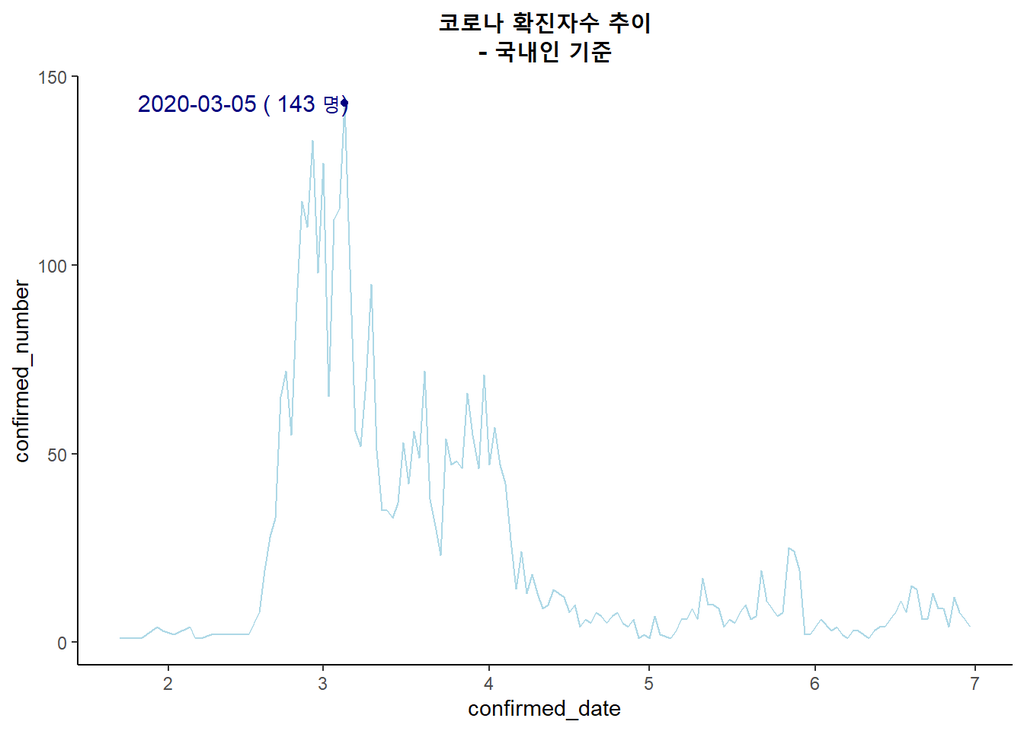

```r
library(ggplot2)
#windowsFonts("Arial" = windowsFont("Arial"))

library(dplyr)
maxs <- data6 %>%filter(confirmed_number == max(data6$confirmed_number))
label_x<-maxs[,c('confirmed_date')] %>% unique
label_x<-format(label_x, format="%Y-%m-%d")
label_y <- maxs[,c('confirmed_number')] %>% unique

p1 <- ggplot() + ggtitle("코로나 확진자수 추이\n- 국내인 기준")+
  geom_line(aes(y = confirmed_number, x = confirmed_date),
color = "lightblue",data = data6, stat="identity")+theme_bw()+theme_classic()+theme(plot.title = element_text(hjust = 0.5,face="bold"))+
  geom_line()+geom_point(data = maxs, aes(x=confirmed_date, y=confirmed_number), colour = 'navy')+
  annotate('text',x=as.Date('2020/02/15', '%Y/%m/%d'),y=143,label=paste(label_x,"(",label_y,"명)"),size=4,colour = 'navy',parse=F)
p1
```

## 문제1-2

Line plot

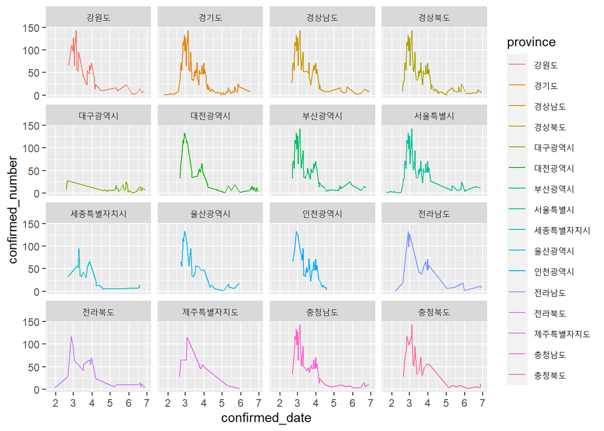

```r
ggplot(data = data6, aes(y = confirmed_number, x = confirmed_date,color = province, group = province)) +
  geom_line()+facet_wrap(~ province)
```

## 문제 2

Bar plot

```r
library("dplyr")
data7<-data6 %>% group_by(province,state) %>% dplyr::summarise(n = n())
data7
```

```
## # A tibble: 37 x 3
## # Groups:   province [16]
##    province state        n
##    <chr>    <chr>    <int>
##  1 강원도   deceased     3
##  2 강원도   isolated    13
##  3 강원도   released    43
##  4 경기도   isolated   768
##  5 경기도   released    57
##  6 경상남도 isolated     6
##  7 경상남도 released   123
##  8 경상북도 deceased    42
##  9 경상북도 isolated   130
## 10 경상북도 released  1068
## # ... with 27 more rows
```

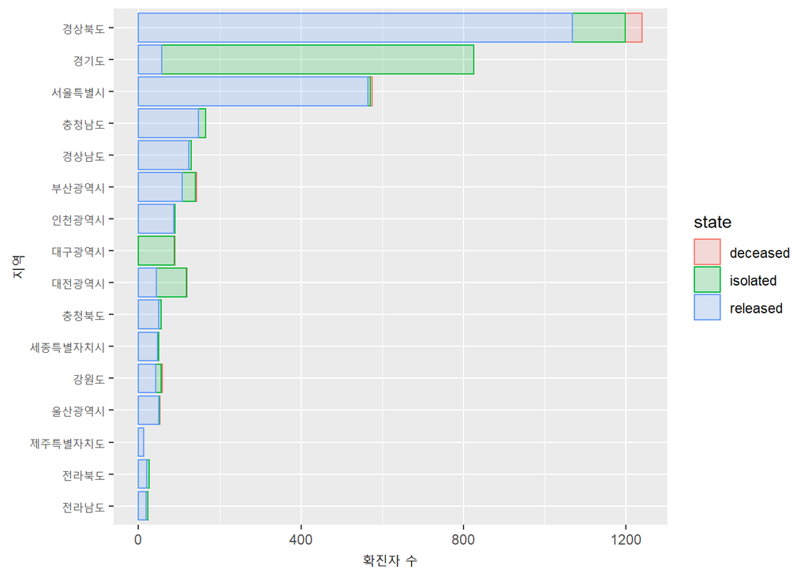

```r
ggplot(data7, aes(y = n, x = reorder(province,n),fill=state,color=state)) +
  geom_bar(stat = "identity",alpha=0.2) + labs(x="지역", y="확진자 수")  +
  scale_y_continuous(breaks=seq(0,1300,400))+coord_flip()
```

## 문제3

Box plot

```r
data8<-data6 %>% group_by(age,confirmed_date)%>% dplyr::summarise(n = n())
```

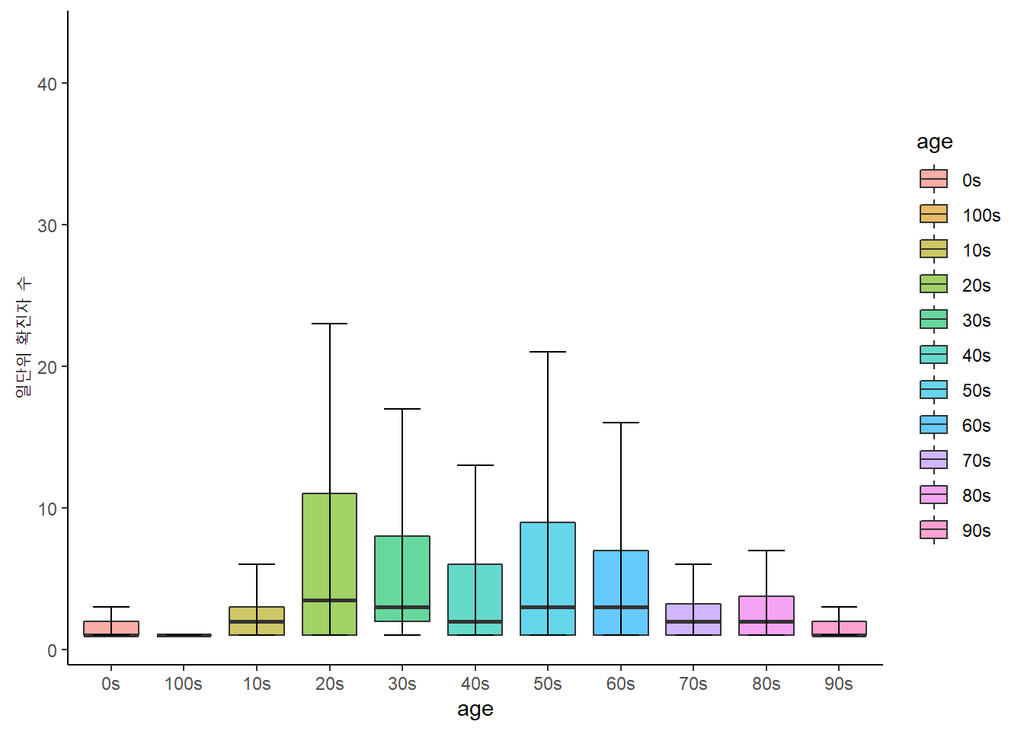

```r
ggplot(data8, aes(x =age, y = n, fill = age)) + labs(x="age", y="일단위 확진자 수")+
  geom_boxplot(alpha=0.6,outlier.shape = NA)+theme_bw()+theme_classic()+scale_color_gradientn(colours = rainbow(10,alpha = 0.1,v=0.7))+
  stat_boxplot(geom='errorbar', linetype=1, width=0.5)
```

## 문제3-2

one-way ANOVA 일원분산분석 결과 연령별, 일별 검정통계량 F-value가 각각8.823과 148.8로 나왔으며, P-value는 각각 8.19e-14, <2e-16로 매우 작게 나와 유의수준 10%에서 귀무가설을 기각하고 대립가설을 채택하게 되어 “연령별, 일별에 따라 확진자 수에 차이가 있다.”라고 해석할 수 있습니다.

```r
age_one.way <- aov(n ~ age, data = data8)
summary(age_one.way)
```

```
##              Df Sum Sq Mean Sq F value   Pr(>F)
## age          10   2575  257.48   8.823 8.19e-14 ***
## Residuals   780  22764   29.18
## ---
## Signif. codes:  0 '***' 0.001 '**' 0.01 '*' 0.05 '.' 0.1 ' ' 1
```

```r
date_one.way <- aov(n ~ confirmed_date, data = data8)
summary(date_one.way)
```

```
##                 Df Sum Sq Mean Sq F value Pr(>F)
## confirmed_date   1   4019    4019   148.8 <2e-16 ***
## Residuals      789  21319      27
## ---
## Signif. codes:  0 '***' 0.001 '**' 0.01 '*' 0.05 '.' 0.1 ' ' 1
```

## Chpater3

### 자료준비

```r
library(MASS)
head(Boston)
```

```
##      crim zn indus chas   nox    rm  age    dis rad tax ptratio  black lstat
## 1 0.00632 18  2.31    0 0.538 6.575 65.2 4.0900   1 296    15.3 396.90  4.98
## 2 0.02731  0  7.07    0 0.469 6.421 78.9 4.9671   2 242    17.8 396.90  9.14
## 3 0.02729  0  7.07    0 0.469 7.185 61.1 4.9671   2 242    17.8 392.83  4.03
## 4 0.03237  0  2.18    0 0.458 6.998 45.8 6.0622   3 222    18.7 394.63  2.94
## 5 0.06905  0  2.18    0 0.458 7.147 54.2 6.0622   3 222    18.7 396.90  5.33
## 6 0.02985  0  2.18    0 0.458 6.430 58.7 6.0622   3 222    18.7 394.12  5.21
##   medv
## 1 24.0
## 2 21.6
## 3 34.7
## 4 33.4
## 5 36.2
## 6 28.7
```